# Session 3

Multi-population Hui-Walter models

Matt Denwood

2022-06-09

## Reminders

All of the material is on the GitHub repository

- We may tweak material as we go along
- Remember to pull changes at the start of each day!
- And click *refresh* in your browser!

R code tips:

- Watch out for errors (red text!) in RStuio output
- You probably need these at the top of every R code file:

```r
library("tidyverse")
library("runjags")
library("PriorGen")
library("TeachingDemos")
```

## Recap

- Fitting models using MCMC is easy with JAGS / runjags
- But we must **never forget** to check convergence and effective sample size!
- More complex models become easy to implement
  - For example imperfect diagnostic tests, and Hui-Walter models
  - But remember to be realistic about what is possible with your data
  - Also carefully consider the influence of your priors

## The multinomial distribution

Binomial (always with two possible outcomes):

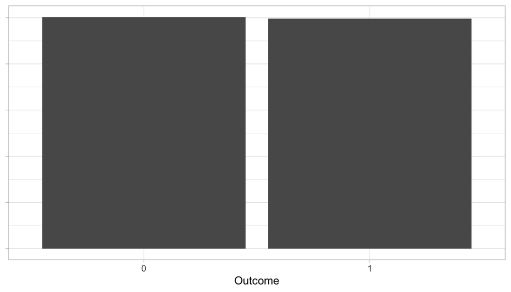

Multinomial with two possible outcomes:

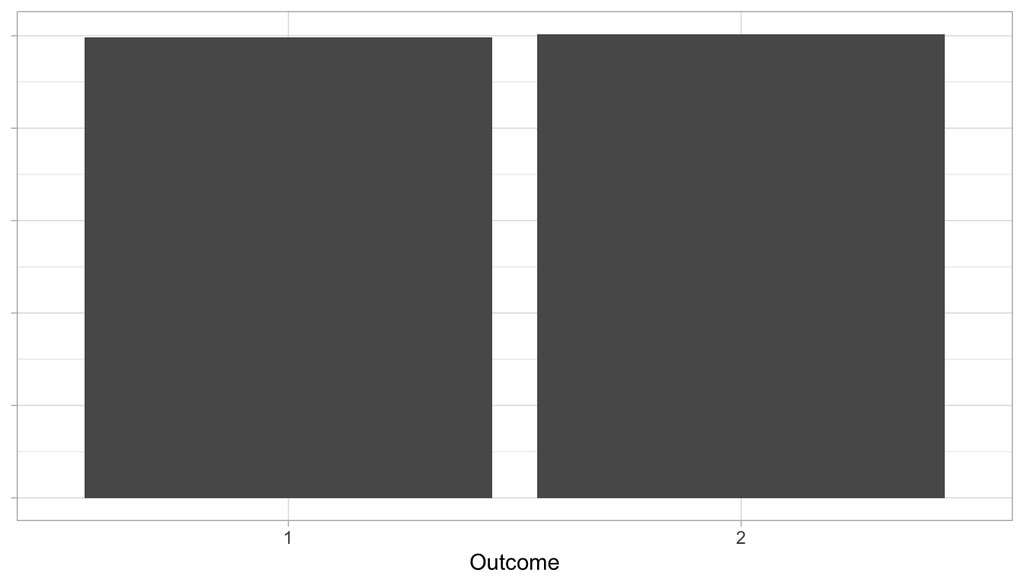

Multinomial with four possible outcomes:

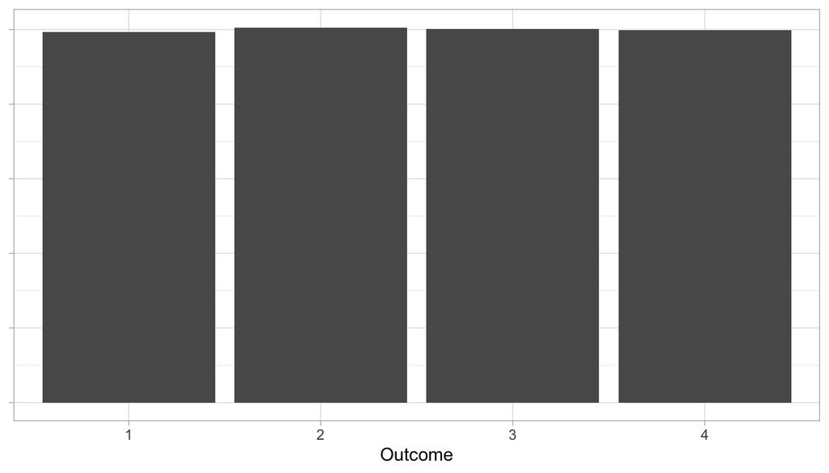

Multinomial with eight possible outcomes:

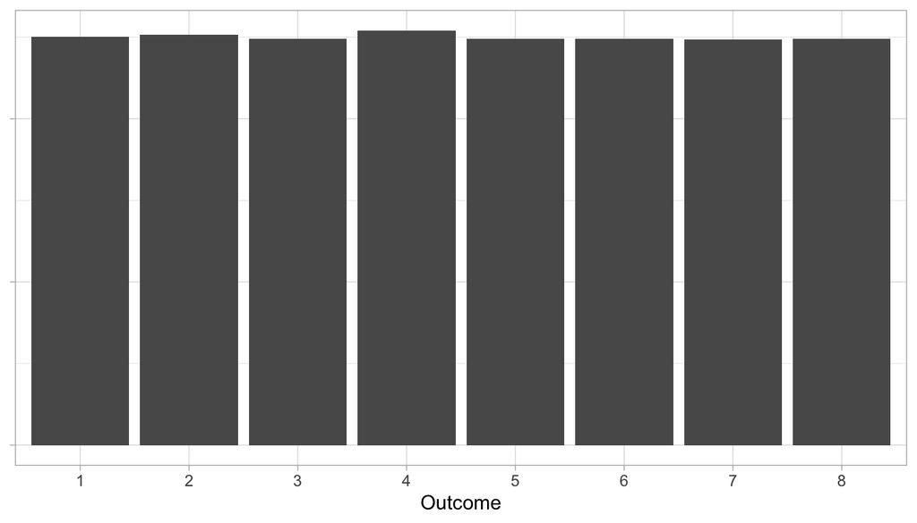

etc!

## Diagnsotic test evaluation with one population

The two-test one-population model we looked at yesterday:

- Has five parameters to estimate:
  - Prevalence, 2 x sensitivity, 2 x specificity
- Has three pieces of information in the data:
  - The number of +/+, +/- and -/+ pairs
  - Remember that N is fixed, so there are only 3 degrees of freedom!
- Is therefore only identifiable with strong priors for one test

How can we improve on this situation?

# The Hui-Walter Paradigm

## Hui-Walter models have multiple populations

- We can extend the one-population idea to multiple populations:
  - Each adds one new parameter (prevalence)
  - But adds three new pieces of information (test results)

Borderline identifiable (parameters = degrees of freedom):

- Two tests, two populations
- Three tests, one population (see later!)

More easily identifiable (parameters < degrees of freedom):

- Two tests, three or more populations

Works best with multiple populations each with differing prevalence

- BUT be wary of assumptions regarding constant sensitivity/specificity!

## Different prevalence in different populations

```r
model{
  for(p in 1:Populations){
    Tally[1:4, p] ~ dmulti(prob[1:4, p], TotalTests[p])
    # Test1- Test2- Pop1
    prob[1, p] <- (prev[p] * ((1-se[1])*(1-se[2]))) + ((1-prev[p]) * ((sp[1])*(sp[2])))

    ## snip ##

    prev[p] ~ dbeta(1, 1)
  }

  se[1] ~ dbeta(1, 1)T(1-sp[1], )
  sp[1] ~ dbeta(1, 1)
  se[2] ~ dbeta(1, 1)T(1-sp[2], )
  sp[2] ~ dbeta(1, 1)

  #data# Tally, TotalTests, Populations
  #monitor# prev, prob, se, sp
  #inits# prev, se, sp
}
```

## Multiple populations: assumptions

- We typically assume that the sensitivity and specificity *must* be consistent between populations
  - Do you have an endemic and epidemic population?
  - Or vaccinated and unvaccinated?
  - If so then the assumptions might not hold!
- The populations can be artificial (e.g. age groups) but must not be decided based on the diagnostic test results
  - It helps if the prevalence differs between the populations

## Multiple populations: special cases

- A small disease-free group is extremely helpful
  - Contains strong data regarding specificity
  - As long as specificity can be assumed to be the same in the other populations
- A small experimentally infected group MAY be helpful but it is often dangerous to assume that sensitivity is consistent!

## Initial values

We have to be careful to make sure that the length of initial values for `prev` in each chain is equal to the number of populations

For example with 5 populations we need:

```r
prev <- list(chain1=c(0.1, 0.1, 0.1, 0.9, 0.9), chain2=c(0.9, 0.9, 0.9, 0.1, 0.1))
```

The values you choose for different populations in the same chain can be the same - just make sure you pick different values for the same population between chains (i.e. *over-dispersed* initial values)

*Note: specifying your own initial values is technically optional with JAGS, but it is always a good idea!!!*

## Incorporating populations with known prevalence

Up to now prevalence has been a parameter, but it can also be (partially) observed:

```r
model{
  for(p in 1:Populations){
    Tally[1:4, p] ~ dmulti(prob[1:4, p], TotalTests[p])
    # Test1- Test2- Pop1
      prob[1, p] <- (prev[p] * ((1-sensitivity[1])*(1-sensitivity[2]))) + ((1-prev[p]) * ((sp[1])*(sp[2])))

      ## snip ##

    prev[p] ~ dbeta(1, 1)
  }

  ## snip ##

  #data# Tally, TotalTests, Populations, se_prior, sp_prior, prev
  #monitor# prev, prob, se, sp
  #inits# prev, se, sp
}
```

To fix the prevalence of population 1 we could do:

```r
Populations <- 5
prev <- rep(NA, Populations)
prev[1] <- 0
prev
## [1]  0 NA NA NA NA
```

But you also need to account for this in the initial values:

```r
prev <- list(chain1=c(NA, 0.1, 0.1, 0.9, 0.9), chain2=c(NA, 0.9, 0.9, 0.1, 0.1))
```

Note: we now have two definitions of `prev` in R!

## Data and initial value lists

There are actually multiple ways to specify data and initial values to runjags, including via the `data` and `inits` arguments

We will use these to keep separate lists of data and initial values (these could also be data frames, or environments)

```r
data <- list(
  Tally = Tally,
  TotalTests = apply(Tally, 2, sum),
  Populations = dim(Tally)[2],
  prev = rep(NA, Populations),
  se_prior = matrix(1, ncol=2, nrow=2),
  sp_prior = matrix(1, ncol=2, nrow=2)
)
data$prev[1] <- 0
```

```r
inits <- list(
  chain1 = list(
    prev = c(NA, 0.1, 0.1, 0.9, 0.9),
    se = c(0.5, 0.99),
    sp = c(0.5, 0.99)
  ),
  chain2 = list(
    prev = c(NA, 0.9, 0.9, 0.1, 0.1),
    se = c(0.99, 0.5),
    sp = c(0.99, 0.5)
  )
)

results <- run.jags(..., data = data, inits = inits)
```

See the help file for `?run.jags` for more details

## Other runjags options

There are a large number of other options to runjags. Some highlights:

- The method can be `parallel` or `background` or `bgparallel`
- You can use `extend.jags` to continue running an existing model (e.g. to increase the sample size)
- You can use `coda::as.mcmc.list` to extract the underlying MCMC chains
- Use the `summary()` method to extract summary statistics
  - See `?summary.runjags` and `?runjagsclass` for more information

## Setting the RNG seed

If we want to get numerically replicable results we need to add `.RNG.name` and `.RNG.seed` to the initial values, and an additional `#modules#` lecuyer hook to our model definition:

```r
  #inits# .RNG.name, .RNG.seed
  #modules# lecuyer
```

Then we can propogate R’s RNG to JAGS like so:

```r
set.seed(2021-06-29)
.RNG.name <<- "lecuyer::RngStream"
.RNG.seed <<- list(chain1=sample.int(1e6, 1), chain2=sample.int(1e6, 1)))
results <- run.jags(model_string, n.chains=2)
```

- Every time this model is run the results will now be identical

# Practical session 3

## Points to consider

1. What are the benefits of including multiple populations?
2. How can we define/obtain these populations?
3. What happens if our fundamental assumptions about consistent Se/Sp are broken?

## Exercise 1

Simulate data using multiple populations. You can use this R code:

```r
# Set a random seed so that the data are reproducible:
set.seed(2021-06-29)

sensitivity <- c(0.9, 0.6)
specificity <- c(0.95, 0.9)
N <- 1000

# Change the number of populations here:
Populations <- 5
# Change the variation in prevalence here:
(prevalence <- runif(Populations, min=0.1, max=0.9))
## [1] 0.4852439 0.2674955 0.5882093 0.3648776 0.5799455
data <- tibble(Population = sample(seq_len(Populations), N, replace=TRUE)) %>%
  mutate(Status = rbinom(N, 1, prevalence[Population])) %>%
  mutate(Test1 = rbinom(N, 1, sensitivity[1]*Status + (1-specificity[1])*(1-Status))) %>%
  mutate(Test2 = rbinom(N, 1, sensitivity[2]*Status + (1-specificity[2])*(1-Status)))

twoXtwoXpop <- with(data, table(Test1, Test2, Population))
Tally <- matrix(twoXtwoXpop, ncol=Populations)
TotalTests <- apply(Tally, 2, sum)
```

Start with 5 populations and analyse the data using the independent prevalence model. Set a RNG seed so that the results are reproducible exactly.

Now try with 1, 3, and 10 populations

- How does this affect the confidence intervals for the diagnostic test parameters?

Now change the simulated prevalence so that it varies between 0.4-0.6 rather than 0.1-0.9

- How does this affect the confidence intervals for the diagnostic test parameters?

### Solution 1

This is what the model should look like:

```
model{
  for(p in 1:Populations){
    Tally[1:4, p] ~ dmulti(prob[1:4, p], TotalTests[p])

    # Test1- Test2-
    prob[1,p] <- (prev[p] * ((1-se[1])*(1-se[2]))) + ((1-prev[p]) * ((sp[1])*(sp[2])))

    # Test1+ Test2-
    prob[2,p] <- (prev[p] * ((se[1])*(1-se[2]))) + ((1-prev[p]) * ((1-sp[1])*(sp[2])))

    # Test1- Test2+
    prob[3,p] <- (prev[p] * ((1-se[1])*(se[2]))) + ((1-prev[p]) * ((sp[1])*(1-sp[2])))

    # Test1+ Test2+
    prob[4,p] <- (prev[p] * ((se[1])*(se[2]))) + ((1-prev[p]) * ((1-sp[1])*(1-sp[2])))

    prev[p] ~ dbeta(1, 1)
  }

  se[1] ~ dbeta(se_prior[1,1], se_prior[1,2])T(1-sp[1], )
  # Or just:
  # se[1] ~ dbeta(1, 1)T(1-sp[1], )

  sp[1] ~ dbeta(sp_prior[1,1], sp_prior[1,2])
  # Or just:
  # sp[1] ~ dbeta(1, 1)

  se[2] ~ dbeta(se_prior[2,1], se_prior[2,2])T(1-sp[2], )
  # Or just:
  # se[2] ~ dbeta(1, 1)T(1-sp[2], )

  sp[2] ~ dbeta(sp_prior[2,1], sp_prior[2,2])
  # Or just:
  # sp[2] ~ dbeta(1, 1)

  # If you are using se_prior and sp_prior then you also need this line:
  #data# se_prior, sp_prior

  #data# Tally, TotalTests, Populations
  #monitor# prev, se, sp
  #inits# prev, se, sp, .RNG.name, .RNG.seed
  #module# lecuyer
}
```

[Note: using `se_prior` and `sp_prior` is optional: you can also put the priors directly into the model code e.g. dbeta(1,1) as before]

Here is the R code to run the model:

```r
# Set a random seed in R:
set.seed(2021-06-29)

# Make sure this is passed to JAGS:
.RNG.name <<- "lecuyer::RngStream"
.RNG.seed <<- list(chain1=sample.int(1e6, 1), chain2=sample.int(1e6, 1))

# Set up the se_prior and sp_prior variables (optional):
se_prior <- matrix(1, nrow=2, ncol=2)
sp_prior <- matrix(1, nrow=2, ncol=2)

# Set up initial values for 5 populations:
se <- list(chain1=c(0.5,0.99), chain2=c(0.99,0.5))
sp <- list(chain1=c(0.5,0.99), chain2=c(0.99,0.5))
prev <- list(chain1=c(0.1, 0.1, 0.1, 0.9, 0.9), chain2=c(0.9, 0.9, 0.9, 0.1, 0.1))

# And run the model:
results_5p <- run.jags("multipopulation.txt", n.chains=2)
## Loading required namespace: rjags
## module lecuyer loaded
# Remember to check convergence!
# plot(results_5p)

results_5p
##
## JAGS model summary statistics from 20000 samples (chains = 2; adapt+burnin = 5000):
##
##         Lower95  Median Upper95    Mean       SD    Mode      MCerr MC%ofSD
## prev[1] 0.39106 0.49295 0.59287  0.4929 0.051744  0.4916  0.0011443     2.2
## prev[2] 0.11864 0.20554 0.30102 0.20716 0.047186  0.2027  0.0010395     2.2
## prev[3] 0.55523 0.66128 0.76647 0.65992 0.054409 0.66846  0.0012057     2.2
## prev[4]  0.2491 0.35858 0.45964 0.35882 0.053394  0.3605  0.0012545     2.3
## prev[5] 0.39539 0.49887 0.59591 0.49851 0.051426 0.50118    0.00108     2.1
## se[1]    0.8309 0.91005 0.99792 0.90848 0.044483 0.91328  0.0010817     2.4
## se[2]   0.58074 0.65233 0.73594 0.65512 0.039972 0.64868 0.00092367     2.3
## sp[1]   0.86094 0.92881 0.99999 0.92749 0.038564 0.92974  0.0009842     2.6
## sp[2]   0.84621 0.89353 0.94653 0.89444 0.025774 0.88955 0.00057822     2.2
##
##         SSeff   AC.10   psrf
## prev[1]  2045   0.178 1.0005
## prev[2]  2060 0.16697 1.0003
## prev[3]  2037 0.17127 1.0001
## prev[4]  1811 0.20012 1.0005
## prev[5]  2267 0.14891 1.0006
## se[1]    1691 0.20089      1
## se[2]    1873 0.18872 1.0007
## sp[1]    1535 0.22637 1.0002
## sp[2]    1987 0.17053 1.0002
##
## Total time taken: 1 seconds
```

To change the number of populations and range of prevalence you just need to modify the simulation code, for example 3 populations with prevalence between 0.4-0.6 can be obtained using:

```r
# Change the number of populations here:
Populations <- 3
# Change the variation in prevalence here:
(prevalence <- runif(Populations, min=0.4, max=0.6))
## [1] 0.5658719 0.5585108 0.5769240
data <- tibble(Population = sample(seq_len(Populations), N, replace=TRUE)) %>%
  mutate(Status = rbinom(N, 1, prevalence[Population])) %>%
  mutate(Test1 = rbinom(N, 1, sensitivity[1]*Status + (1-specificity[1])*(1-Status))) %>%
  mutate(Test2 = rbinom(N, 1, sensitivity[2]*Status + (1-specificity[2])*(1-Status)))

(twoXtwoXpop <- with(data, table(Test1, Test2, Population)))
## , , Population = 1
##
##      Test2
## Test1   0   1
##     0 122  25
##     1  75  92
##
## , , Population = 2
##
##      Test2
## Test1   0   1
##     0 108  24
##     1  73 109
##
## , , Population = 3
##
##      Test2
## Test1   0   1
##     0 148  16
##     1 103 105
(Tally <- matrix(twoXtwoXpop, ncol=Populations))
##      [,1] [,2] [,3]
## [1,]  122  108  148
## [2,]   75   73  103
## [3,]   25   24   16
## [4,]   92  109  105
(TotalTests <- apply(Tally, 2, sum))
## [1] 314 314 372
# Adjust initial values for 3 populations:
se <- list(chain1=c(0.5,0.99), chain2=c(0.99,0.5))
sp <- list(chain1=c(0.5,0.99), chain2=c(0.99,0.5))
prev <- list(chain1=c(0.1, 0.1, 0.9), chain2=c(0.9, 0.9, 0.1))

# And run the model:
results_3p <- run.jags("multipopulation.txt", n.chains=2)

# Remember to check convergence!
# plot(results_3p)

results_3p
##
## JAGS model summary statistics from 20000 samples (chains = 2; adapt+burnin = 5000):
##
##         Lower95  Median Upper95    Mean       SD    Mode     MCerr MC%ofSD
## prev[1] 0.27204 0.40981 0.58698 0.41769 0.082587 0.39692 0.0041337       5
## prev[2] 0.33393 0.47974 0.64763 0.48585 0.082731 0.46826 0.0042054     5.1
## prev[3] 0.24469 0.37673 0.56233 0.39066 0.085202 0.34583 0.0047787     5.6
## se[1]    0.8061 0.87525 0.98953 0.88313 0.050268 0.85786 0.0017209     3.4
## se[2]   0.59764 0.79707 0.99998 0.79323  0.11763 0.79989 0.0065139     5.5
## sp[1]    0.5679 0.67418 0.87685 0.69575  0.08544 0.64671 0.0051051       6
## sp[2]   0.85789 0.93767 0.99999 0.93349 0.043485 0.97015 0.0014829     3.4
##
##         SSeff   AC.10   psrf
## prev[1]   399 0.62631 1.0014
## prev[2]   387 0.63223 1.0006
## prev[3]   318 0.68919 1.0035
## se[1]     853 0.42526 1.0074
## se[2]     326 0.70834 1.0047
## sp[1]     280 0.73548 1.0112
## sp[2]     860 0.43006 1.0066
##
## Total time taken: 0.8 seconds
```

Note that the effective sample size is not enough here - you either need to run the model for longer in the first place, or extend it to get more samples:

```r
# Extend the model:
results_3p <- extend.jags(results_3p, sample=50000)

# Remember to check convergence!
# plot(results_3p)

results_3p
##
## JAGS model summary statistics from 120000 samples (chains = 2; adapt+burnin = 5000):
##
##         Lower95  Median Upper95    Mean       SD    Mode      MCerr MC%ofSD
## prev[1] 0.26633 0.40653 0.58321 0.41459 0.082528 0.39001  0.0018343     2.2
## prev[2] 0.33155 0.47566 0.64906 0.48222 0.083497 0.45825   0.001867     2.2
## prev[3] 0.24173 0.37424  0.5625 0.38708 0.084581 0.35488  0.0020249     2.4
## se[1]   0.80429 0.87458 0.98784 0.88281 0.050215  0.8557 0.00072812     1.5
## se[2]   0.60103 0.80437 0.99978 0.79954  0.11589 0.81269  0.0027199     2.3
## sp[1]   0.57155 0.67035 0.87483 0.69136 0.083434 0.64241  0.0020692     2.5
## sp[2]   0.85828 0.93879       1 0.93391  0.04342 0.97058 0.00063876     1.5
##
##         SSeff   AC.10   psrf
## prev[1]  2024 0.63591 1.0017
## prev[2]  2000 0.63788 1.0016
## prev[3]  1745 0.69078  1.002
## se[1]    4756 0.43076      1
## se[2]    1816 0.70834 1.0027
## sp[1]    1626 0.73436 1.0031
## sp[2]    4621 0.44604 1.0001
##
## Total time taken: 2.6 seconds
```

As a general rule, the more populations you have, and the more the prevalence varies between them, the better. With two tests, we really need two or more populations for the model to be identifiable. However, this is conditional on having a consistent sensitivity and specificity between your populations!!!

## Exercise 2

For this exercise you will need to use the “multi_pop_data.Rdata” file under “Day2” on the GitHub repository. You should just be able to load this by double clicking on it, otherwise you can choose `Session` and `Load Workspace` in RStudio and select the file to load. You should then be able to look at the data:

```r
multi_pop_data %>% count(Population, Test1, Test2)
## # A tibble: 12 × 4
##    Population            Test1 Test2     n
##    <fct>                 <int> <int> <int>
##  1 CertifiedFree             0     0    97
##  2 CertifiedFree             0     1    10
##  3 CertifiedFree             1     0     4
##  4 CertifiedFree             1     1     1
##  5 NaturalInfection          0     0   444
##  6 NaturalInfection          0     1    92
##  7 NaturalInfection          1     0    76
##  8 NaturalInfection          1     1   162
##  9 ExperimentalInfection     0     0     1
## 10 ExperimentalInfection     0     1     3
## 11 ExperimentalInfection     1     0     3
## 12 ExperimentalInfection     1     1   107
```

There are 3 populations:

- The CertifiedFree population is individuals that are known to be free of disease due to their geographical location. You can assume that none of these animals are truly infected.
- The NaturalInfection population is the main population of interest, where some animals will be infected and some will be uninfected.
- The ExperimentalInfection population have been experimentally infected with an extremely large infectious dose of the causative agent of your disease, whilst being kept isolated from any other possible disease. You can assume that all of these individuals are infected.

Fit a 2-test, 3-population model to this data using minimally informative Beta(1,1) priors. Interpret the results. How well is sensitivity and specificity estimated relative to the other datsaets we have looked at? Why might there be a difference here?

Now exclude individuals in the ExperimentalInfection population and re-run the model. Do the estimated results change? Why might that be?

### Solution 2

First we need to make a minor change to the model to include #data# prev - only 1 line of this model has changed compared to before:

```
model{
  for(p in 1:Populations){
    Tally[1:4, p] ~ dmulti(prob[1:4, p], TotalTests[p])

    # Test1- Test2-
      prob[1,p] <- (prev[p] * ((1-se[1])*(1-se[2]))) + ((1-prev[p]) * ((sp[1])*(sp[2])))

    # Test1+ Test2-
    prob[2,p] <- (prev[p] * ((se[1])*(1-se[2]))) + ((1-prev[p]) * ((1-sp[1])*(sp[2])))

    # Test1- Test2+
    prob[3,p] <- (prev[p] * ((1-se[1])*(se[2]))) + ((1-prev[p]) * ((sp[1])*(1-sp[2])))

     # Test1+ Test2+
      prob[4,p] <- (prev[p] * ((se[1])*(se[2]))) + ((1-prev[p]) * ((1-sp[1])*(1-sp[2])))

    prev[p] ~ dbeta(1, 1)
  }

  se[1] ~ dbeta(se_prior[1,1], se_prior[1,2])T(1-sp[1], )
  sp[1] ~ dbeta(sp_prior[1,1], sp_prior[1,2])
  se[2] ~ dbeta(se_prior[2,1], se_prior[2,2])T(1-sp[2], )
  sp[2] ~ dbeta(sp_prior[2,1], sp_prior[2,2])

  #data# se_prior, sp_prior

  # The new line:
  #data# prev

  #data# Tally, TotalTests, Populations
  #monitor# prev, se, sp
  #inits# prev, se, sp, .RNG.name, .RNG.seed
  #module# lecuyer
}
```

Then we need to summarise the data in the format needed by the model. This is the same process as for the simulated data, except that we will use a list to keep our data separate from our initial values:

```r
(twoXtwoXpop <- with(multi_pop_data, table(Test1, Test2, Population)))
## , , Population = CertifiedFree
##
##      Test2
## Test1   0   1
##     0  97  10
##     1   4   1
##
## , , Population = NaturalInfection
##
##      Test2
## Test1   0   1
##     0 444  92
##     1  76 162
##
## , , Population = ExperimentalInfection
##
##      Test2
## Test1   0   1
##     0   1   3
##     1   3 107
(Tally <- matrix(twoXtwoXpop, ncol=dim(twoXtwoXpop)[3]))
##      [,1] [,2] [,3]
## [1,]   97  444    1
## [2,]    4   76    3
## [3,]   10   92    3
## [4,]    1  162  107
data <- list(
  Tally = Tally,
  TotalTests = apply(Tally, 2, sum),
  Populations = dim(twoXtwoXpop)[3],
  prev = rep(NA, dim(twoXtwoXpop)[3]),
  se_prior = matrix(1, ncol=2, nrow=2),
  sp_prior = matrix(1, ncol=2, nrow=2)
)
```

Then we need to add data corresponding to the known prevalence in the first and third population, but leave it missing in the second:

```r
data$prev <- c(0.0, NA, 1.0)
# This is just for illustration - names are ignored by JAGS:
names(data$prev) <- levels(multi_pop_data$Population)
data$prev
##         CertifiedFree      NaturalInfection ExperimentalInfection
##                     0                    NA                     1
```

Then we can set appropriate initial values and run the model:

```r
inits <- list(
  chain1 = list(
    prev = c(NA, 0.1, NA),
    se = c(0.5, 0.99),
    sp = c(0.5, 0.99)
  ),
  chain2 = list(
    prev = c(NA, 0.9, NA),
    se = c(0.99, 0.5),
    sp = c(0.99, 0.5)
  )
)

results_3p <- run.jags("multipopulation_fixprev.txt", n.chains=2, data = data, inits = inits)

# Note: this is only commented out to save space in the exercise file!
# plot(results_3p)
# check convergence and effective sample size, and then interpret results:
results_3p
##
## JAGS model summary statistics from 20000 samples (chains = 2; adapt+burnin = 5000):
##
##         Lower95  Median Upper95    Mean       SD    Mode      MCerr MC%ofSD
## prev[1]       0       0       0       0        0       0         --      --
## prev[2] 0.18445 0.22059 0.26028 0.22125  0.01951 0.21889 0.00023854     1.2
## prev[3]       1       1       1       1        0       1         --      --
## se[1]   0.91068  0.9548  0.9873 0.95198 0.020766 0.95992 0.00024269     1.2
## se[2]    0.9034 0.94981 0.98775 0.94692 0.022632 0.95385 0.00029286     1.3
## sp[1]    0.8559 0.88535 0.91478 0.88519 0.015108 0.88634 0.00017965     1.2
## sp[2]    0.8217 0.85257 0.88142 0.85244 0.015303 0.85288 0.00015459       1
##
##         SSeff      AC.10    psrf
## prev[1]    --         --      --
## prev[2]  6689  0.0032993 0.99999
## prev[3]    --         --      --
## se[1]    7322  0.0080902  1.0001
## se[2]    5972  0.0037884  1.0001
## sp[1]    7073 0.00096158 0.99995
## sp[2]    9798  0.0086152  1.0001
##
## Total time taken: 0.5 seconds
```

The 95% CI for sensitivity and specificity of both tests are extremely narrow compared to the previous dataset with the same minimally informative priors. This is because of the 1st and 3rd population: because we know the prevalence is 0 or 1, the latent state is no longer latent so the model is *much* better identified. This has a knock-on effect to population 2 because we assume the sensitivty and specificity are the same.

Re-running the model for the first 2 populations is quite straightforward:

```r
(twoXtwoXpop <- with(multi_pop_data, table(Test1, Test2, Population, exclude="ExperimentalInfection")))
## , , Population = CertifiedFree
##
##      Test2
## Test1   0   1
##     0  97  10
##     1   4   1
##
## , , Population = NaturalInfection
##
##      Test2
## Test1   0   1
##     0 444  92
##     1  76 162
Populations <- dim(twoXtwoXpop)[3]
stopifnot(Populations==2)

(Tally <- matrix(twoXtwoXpop, ncol=Populations))
##      [,1] [,2]
## [1,]   97  444
## [2,]    4   76
## [3,]   10   92
## [4,]    1  162
data <- list(
  Tally = Tally,
  TotalTests = apply(Tally, 2, sum),
  Populations = dim(twoXtwoXpop)[3],
  prev = c(0.0, NA),
  se_prior = matrix(1, ncol=2, nrow=2),
  sp_prior = matrix(1, ncol=2, nrow=2)
)

inits <- list(
  chain1 = list(
    prev = c(NA, 0.1),
    se = c(0.5, 0.99),
    sp = c(0.5, 0.99)
  ),
  chain2 = list(
    prev = c(NA, 0.9),
    se = c(0.99, 0.5),
    sp = c(0.99, 0.5)
  )
)

results_2p <- run.jags("multipopulation_fixprev.txt", n.chains=2, data = data, inits = inits)

# Note: this is only commented out to save space in the exercise file!
# plot(results_2p)
# check convergence and effective sample size, and then interpret results:
results_2p
##
## JAGS model summary statistics from 20000 samples (chains = 2; adapt+burnin = 5000):
##
##         Lower95  Median Upper95    Mean       SD    Mode      MCerr MC%ofSD
## prev[1]       0       0       0       0        0       0         --      --
## prev[2] 0.26327 0.34075 0.41792 0.33979  0.03996 0.33976  0.0010164     2.5
## se[1]   0.67061 0.79455 0.94648 0.80083 0.070841 0.78783  0.0017269     2.4
## se[2]      0.66 0.75226  0.8674 0.75781 0.053446 0.74411   0.001107     2.1
## sp[1]   0.90139 0.94803 0.98183 0.94514 0.021468 0.95101 0.00043785       2
## sp[2]   0.84144 0.89387 0.94134 0.89296 0.025956 0.89392 0.00060657     2.3
##
##         SSeff   AC.10    psrf
## prev[1]    --      --      --
## prev[2]  1546 0.21286  1.0001
## se[1]    1683 0.19281  1.0002
## se[2]    2331 0.10409 0.99997
## sp[1]    2404 0.09583  1.0003
## sp[2]    1831 0.17803  1.0001
##
## Total time taken: 0.4 seconds
```

The sensitivity of both tests is now much more poorly estimated because we don’t have a known positive population on which to base this estimate. Furthermore, the posteriors have generally shifted downwards compared to the 3 population model. We can illustrate this using a graph:

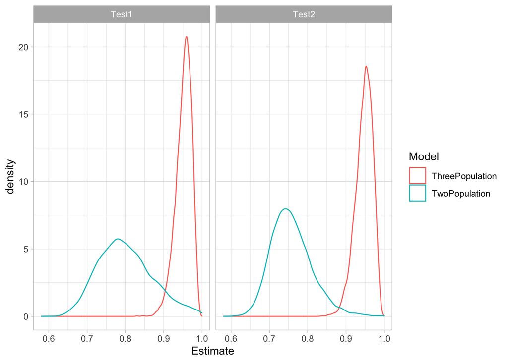

```r
pop2 <- combine.mcmc(results_2p, vars="se", return.samples = 10000)
pop3 <- combine.mcmc(results_3p, vars="se", return.samples = 10000)

bind_rows(
  tibble(Model = "TwoPopulation", Test1 = pop2[,"se[1]"], Test2 = pop2[,"se[2]"]),
  tibble(Model = "ThreePopulation", Test1 = pop3[,"se[1]"], Test2 = pop3[,"se[2]"])
) %>%
  pivot_longer(c(Test1, Test2), names_to = "Test", values_to = "Estimate") %>%
  ggplot() +
  aes(x = Estimate, col = Model) +
  geom_density() +
  facet_wrap( ~ Test)
```

We can conclude that there is most likely something different about the sensitivity in the experimentally infected individuals. This might have something to do with them being given an extremely large infectious dose that does not even vaguely represent the real world…

We can also look at the specificity:

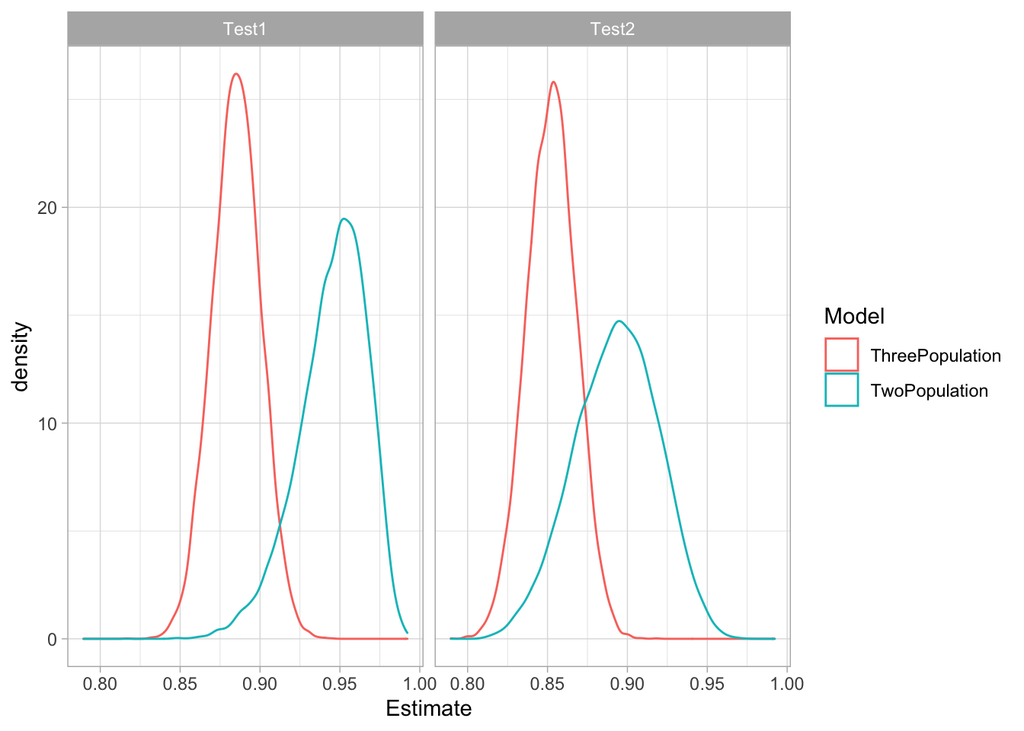

```r
pop2 <- combine.mcmc(results_2p, vars="sp", return.samples = 10000)
pop3 <- combine.mcmc(results_3p, vars="sp", return.samples = 10000)

bind_rows(
  tibble(Model = "TwoPopulation", Test1 = pop2[,"sp[1]"], Test2 = pop2[,"sp[2]"]),
  tibble(Model = "ThreePopulation", Test1 = pop3[,"sp[1]"], Test2 = pop3[,"sp[2]"])
) %>%
  pivot_longer(c(Test1, Test2), names_to = "Test", values_to = "Estimate") %>%
  ggplot() +
  aes(x = Estimate, col = Model) +
  geom_density() +
  facet_wrap( ~ Test)
```

## Optional exercise A

Simulate data for a much larger number of populations using the code from exercise 1

- Start with 100 populations and a total N of 1000 (i.e. 10 individuals per population, on average)
- Fit the model assuming independent prevalence
- What do you notice about the parameter estimates compared to having 5 populations with the same total N?

Note: runjags will not provide summary statistics if you have >50 monitored variables, but you can ask for summary statistics for specific variables like so:

```r
summary(results, vars="se[1]")
summary(results, vars="se")
# Or using partial matching for any variable beginning with s:
summary(results, vars="^s")

# This argument can be vectorised, allows ranges to be specified, and also works with plots:
plot(results, vars=c("^s", "prev[1:5]"))
```

Alternatively, if you really want all summary statistics to be calculated automatically you can set:

```r
runjags.options(force.summary=TRUE)
```

### Solution A

```r
N <- 1000
Populations <- 100
(prevalence <- runif(Populations, min=0.1, max=0.9))
##   [1] 0.4695402 0.8652087 0.7135862 0.1097742 0.4529482 0.6146181 0.1105493
##   [8] 0.7721661 0.8977295 0.3375450 0.3489044 0.6571235 0.5846070 0.4510891
##  [15] 0.5218948 0.6841502 0.7476634 0.3502736 0.3855031 0.1718497 0.6549774
##  [22] 0.4777447 0.1039167 0.1194671 0.1042029 0.5238198 0.7208027 0.2479470
##  [29] 0.4563629 0.3213209 0.7593683 0.5257662 0.8147132 0.2967973 0.7312115
##  [36] 0.1065881 0.5118978 0.6393284 0.7459335 0.7167498 0.3025328 0.5074857
##  [43] 0.2961918 0.6662344 0.6965757 0.6477580 0.8397716 0.4539770 0.3775035
##  [50] 0.8905239 0.5847723 0.5591701 0.2219727 0.2045240 0.5644230 0.1402526
##  [57] 0.8027511 0.5461266 0.7768322 0.1907124 0.2422841 0.3685476 0.7788658
##  [64] 0.5023534 0.8773930 0.4430183 0.5467091 0.8773065 0.6506561 0.8506716
##  [71] 0.6860503 0.7164092 0.8858578 0.5415387 0.8814657 0.5181589 0.6448724
##  [78] 0.8596402 0.4557583 0.4071211 0.8568184 0.4313254 0.1940845 0.3199770
##  [85] 0.2088249 0.2915562 0.6740927 0.1906713 0.2263571 0.8225923 0.2231564
##  [92] 0.3131532 0.4187525 0.6110798 0.7844981 0.7993413 0.2741343 0.6871505
##  [99] 0.3438334 0.7365238
data <- tibble(Population = sample(seq_len(Populations), N, replace=TRUE)) %>%
  mutate(Status = rbinom(N, 1, prevalence[Population])) %>%
  mutate(Test1 = rbinom(N, 1, sensitivity[1]*Status + (1-specificity[1])*(1-Status))) %>%
  mutate(Test2 = rbinom(N, 1, sensitivity[2]*Status + (1-specificity[2])*(1-Status)))

twoXtwoXpop <- with(data, table(Test1, Test2, Population))
Tally <- matrix(twoXtwoXpop, ncol=Populations)
TotalTests <- apply(Tally, 2, sum)

# Adjust initial values for an arbitrary number of populations:
se <- list(chain1=c(0.5,0.99), chain2=c(0.99,0.5))
sp <- list(chain1=c(0.5,0.99), chain2=c(0.99,0.5))
prev <- list(chain1=rep(0.1, Populations), chain2=rep(0.9, Populations))

# And run the model:
results_100p <- run.jags("multipopulation.txt", n.chains=2)

# Remember to check convergence!
# plot(results_100p, vars=c("^s", "prev[1:5]"))

results_100p
##
## JAGS model with 20000 samples (chains = 2; adapt+burnin = 5000)
##
## Full summary statistics have not been pre-calculated - use either the summary method or add.summary to calculate summary statistics
summary(results_100p, vars=c("^s", "prev[1:5]"))
##              Lower95     Median   Upper95      Mean         SD       Mode
## se[1]   8.437834e-01 0.90242017 0.9566252 0.9019071 0.02915607 0.90375088
## se[2]   5.451877e-01 0.60040071 0.6582015 0.6009443 0.02900188 0.60181154
## sp[1]   8.231586e-01 0.89244361 0.9574956 0.8924425 0.03439537 0.89317620
## sp[2]   8.518099e-01 0.89371740 0.9358133 0.8929858 0.02149316 0.89420680
## prev[1] 5.076518e-02 0.31509860 0.6082565 0.3267300 0.14774780 0.30429901
## prev[2] 6.448297e-01 0.90591080 0.9999989 0.8741676 0.11288808 0.95779193
## prev[3] 3.658694e-01 0.80381780 0.9999691 0.7561806 0.19574483 0.90971417
## prev[4] 7.965216e-06 0.08990412 0.3373669 0.1208368 0.10810159 0.04041399
## prev[5] 4.535719e-05 0.38948052 0.8447720 0.4088976 0.24844817 0.28000963
##                MCerr MC%ofSD SSeff        AC.10     psrf
## se[1]   0.0005139474     1.8  3218  0.044195148 1.000075
## se[2]   0.0004263916     1.5  4626  0.017473099 1.000164
## sp[1]   0.0006298279     1.8  2982  0.066997274 1.000876
## sp[2]   0.0003330310     1.5  4165  0.037965521 1.000438
## prev[1] 0.0014041468     1.0 11072  0.004637774 1.000464
## prev[2] 0.0016284629     1.4  4806 -0.001334550 1.000011
## prev[3] 0.0025320324     1.3  5976  0.010333332 1.000038
## prev[4] 0.0015543294     1.4  4837  0.025575833 1.000130
## prev[5] 0.0024423331     1.0 10348  0.004964386 1.000110
```

The confidence intervals for prevalence in each population are extremely wide! But how do the estimates for the diagnostic test characteristics compare to using 5 populations:

```r
results_5p
##
## JAGS model summary statistics from 20000 samples (chains = 2; adapt+burnin = 5000):
##
##         Lower95  Median Upper95    Mean       SD    Mode      MCerr MC%ofSD
## prev[1] 0.39106 0.49295 0.59287  0.4929 0.051744  0.4916  0.0011443     2.2
## prev[2] 0.11864 0.20554 0.30102 0.20716 0.047186  0.2027  0.0010395     2.2
## prev[3] 0.55523 0.66128 0.76647 0.65992 0.054409 0.66846  0.0012057     2.2
## prev[4]  0.2491 0.35858 0.45964 0.35882 0.053394  0.3605  0.0012545     2.3
## prev[5] 0.39539 0.49887 0.59591 0.49851 0.051426 0.50118    0.00108     2.1
## se[1]    0.8309 0.91005 0.99792 0.90848 0.044483 0.91328  0.0010817     2.4
## se[2]   0.58074 0.65233 0.73594 0.65512 0.039972 0.64868 0.00092367     2.3
## sp[1]   0.86094 0.92881 0.99999 0.92749 0.038564 0.92974  0.0009842     2.6
## sp[2]   0.84621 0.89353 0.94653 0.89444 0.025774 0.88955 0.00057822     2.2
##
##         SSeff   AC.10   psrf
## prev[1]  2045   0.178 1.0005
## prev[2]  2060 0.16697 1.0003
## prev[3]  2037 0.17127 1.0001
## prev[4]  1811 0.20012 1.0005
## prev[5]  2267 0.14891 1.0006
## se[1]    1691 0.20089      1
## se[2]    1873 0.18872 1.0007
## sp[1]    1535 0.22637 1.0002
## sp[2]    1987 0.17053 1.0002
##
## Total time taken: 1 seconds
```

## Optional exercise B

Note: this exercise is a bit tricky, and is also related to topic 7. So if you don’t get it finished today you can come back to it on the last day!

The problem with exercise A is that there are too many populations to allow the prevalence to be completely independent between them. This can be solved in one of two ways:

1. Constrain the variation between populations by fitting the prevalences to a single distribution, and estimate the mean and variance of this distribution. This is analogous to fitting a random effect of population rather than a fixed effect of population.
2. Fit a random effect of population plus predictor variables to the population-level prevalence to explain some of the variation.

Note: this has clear parallels with a generalised linear model - we will return to this idea for topic 7.

In this case we don’t have any explanatory variables, but we can fit a random effect of population to constrain the prevalence parameters. See if you can adapt the multi-population model to do this. Take inspiration from how you might specify a logistic regression with random effect of population.

Hint: the following JAGS code might be useful:

```r
logit(prev[p]) <- intercept + population_effect[p]
population_effect[p] ~ dnorm(0, tau)
```

This introduces the normal distribution, which is parameterised using mean and precision (= inverse variance) in JAGS. For more information on distributions that are available in JAGS see the jags_user_manual provided in the GitHub repo.

### Solution B

This was quite tricky, so if you managed to get close to the solution without cheating then you have done well!

```
model{
  for(p in 1:Populations){
    Tally[1:4, p] ~ dmulti(prob[1:4, p], TotalTests[p])

    # Test1- Test2-
    prob[1,p] <- (prev[p] * ((1-se[1])*(1-se[2]))) + ((1-prev[p]) * ((sp[1])*(sp[2])))

    # Test1+ Test2-
    prob[2,p] <- (prev[p] * ((se[1])*(1-se[2]))) + ((1-prev[p]) * ((1-sp[1])*(sp[2])))

    # Test1- Test2+
    prob[3,p] <- (prev[p] * ((1-se[1])*(se[2]))) + ((1-prev[p]) * ((sp[1])*(1-sp[2])))

    # Test1+ Test2+
    prob[4,p] <- (prev[p] * ((se[1])*(se[2]))) + ((1-prev[p]) * ((1-sp[1])*(1-sp[2])))

    logit(prev[p]) <- intercept + population_effect[p]
    population_effect[p] ~ dnorm(0, tau)
  }

  # Priors for the intercept and precision of the random effect:
  intercept ~ dnorm(0, 0.33)
  tau ~ dgamma(0.01, 0.01)

  se[1] ~ dbeta(se_prior[1,1], se_prior[1,2])T(1-sp[1], )
  sp[1] ~ dbeta(sp_prior[1,1], sp_prior[1,2])
  se[2] ~ dbeta(se_prior[2,1], se_prior[2,2])T(1-sp[2], )
  sp[2] ~ dbeta(sp_prior[2,1], sp_prior[2,2])

  #data# se_prior, sp_prior

  #data# Tally, TotalTests, Populations
  #monitor# prev[1], se, sp, tau, intercept
  #inits# se, sp, tau, intercept, .RNG.name, .RNG.seed
  #modules# lecuyer
}
```

Then we can simulate the data:

```r
# Set a random seed so that the data are reproducible:
set.seed(2021-06-29)

sensitivity <- c(0.9, 0.6)
specificity <- c(0.95, 0.9)
N <- 1000

Populations <- 100
prevalence <- runif(Populations, min=0.1, max=0.9)

data <- tibble(Population = sample(seq_len(Populations), N, replace=TRUE)) %>%
  mutate(Status = rbinom(N, 1, prevalence[Population])) %>%
  mutate(Test1 = rbinom(N, 1, sensitivity[1]*Status + (1-specificity[1])*(1-Status))) %>%
  mutate(Test2 = rbinom(N, 1, sensitivity[2]*Status + (1-specificity[2])*(1-Status)))

twoXtwoXpop <- with(data, table(Test1, Test2, Population))
Tally <- matrix(twoXtwoXpop, ncol=Populations)
TotalTests <- apply(Tally, 2, sum)
```

You will also need to set initial values for tau and the intercept (but not for prev, as we take care of this via the intercept):

```r
se <- list(chain1=c(0.5,0.99), chain2=c(0.99,0.5))
sp <- list(chain1=c(0.5,0.99), chain2=c(0.99,0.5))
tau <- list(chain1 = 0.01, chain2 = 100)
intercept <- list(chain1 = -4, chain2 = 4)
set.seed(2021-06-29)
.RNG.name <<- "lecuyer::RngStream"
.RNG.seed <<- list(chain1=sample.int(1e6, 1), chain2=sample.int(1e6, 1))
```

Remember that the intercept is on the logit scale, so -4 corresponds to a prevalence of 0.0179862 and 4 corresponds to a prevalence of 0.9820138. These are quite widely over-dispersed!

The code to run the model is very similar to before:

```r
results_random <- run.jags("multirandom.txt", n.chains=2, method="parallel", sample=20000)

# Note: this is only commented out to save space in the exercise file!
# plot(results_random)
# check convergence and effective sample size, and then interpret results:
results_random
##
## JAGS model summary statistics from 40000 samples (chains = 2; adapt+burnin = 5000):
##
##            Lower95   Median Upper95     Mean       SD     Mode      MCerr
## prev[1]    0.36355  0.64594 0.90009  0.64023  0.14178  0.66171  0.0011164
## se[1]      0.78516  0.85993 0.94027  0.86077 0.039292  0.85757 0.00067837
## se[2]      0.59625  0.66393 0.74019  0.66456 0.036644  0.66338 0.00058445
## sp[1]      0.83224   0.8993 0.97456  0.89994 0.036538  0.89606 0.00067071
## sp[2]      0.86117  0.91311 0.96566  0.91307 0.026573  0.91322 0.00045476
## tau        0.33651  0.67835  1.1775  0.71466  0.23048  0.61744  0.0042053
## intercept -0.61832 -0.13054 0.31407 -0.13138  0.23793 -0.11841  0.0053473
##
##           MC%ofSD SSeff    AC.10    psrf
## prev[1]       0.8 16130 0.010115 0.99999
## se[1]         1.7  3355  0.19946  1.0003
## se[2]         1.6  3931  0.16144  1.0007
## sp[1]         1.8  2968  0.22426  1.0008
## sp[2]         1.7  3415  0.18548  1.0004
## tau           1.8  3004  0.23548  1.0003
## intercept     2.2  1980  0.36019  1.0001
##
## Total time taken: 10 seconds
```

Note: when fitting a random effect we might not be interested in the estimates for each population as much as the overall intercept and precision (tau). But there is nothing to stop us also extracting estimates for a specific population - I have done this for the first population for illustration.

## Summary

- Multiple populations helps to estimate Se and Sp
  - Particularly if the prevalences differ
  - A minimum of two populations is generally needed
- Populations may be artificial
  - But cannot be based on the result of either test
- But if Se / Sp are inconsistent then we will get misleading results
  - In practice, groups with widely varying prevalence rarely have consistent Se / Sp
  - It is possible to allow Se / Sp to differ between populations, but then there is no benefit of combining the data